# (Prosper Loan Data Exploration )

## Preliminary Wrangling

> This data set contains 113,937 loans' reuqests data with 81 variables on each loan, including loan amount, borrower rate (or interest rate), current loan status, borrower income, and many others.

```python
# import all packages and set plots to be embedded inline
import numpy as np
import pandas as pd
import matplotlib.pyplot as plt
import seaborn as sb

%matplotlib inline
```

### Loading the data

```python
df=pd.read_csv("ProsperLoanData.csv")
print(df.shape)
print(df.head())
```

```
(113937, 81)
                ListingKey  ListingNumber            ListingCreationDate  \
0  1021339766868145413AB3B         193129  2007-08-26 19:09:29.263000000
1  10273602499503308B223C1        1209647  2014-02-27 08:28:07.900000000
2  0EE9337825851032864889A          81716  2007-01-05 15:00:47.090000000
3  0EF5356002482715299901A         658116  2012-10-22 11:02:35.010000000
4  0F023589499656230C5E3E2         909464  2013-09-14 18:38:39.097000000

  CreditGrade  Term LoanStatus           ClosedDate  BorrowerAPR  \
0           C    36  Completed  2009-08-14 00:00:00      0.16516
1         NaN    36    Current                  NaN      0.12016
2          HR    36  Completed  2009-12-17 00:00:00      0.28269
3         NaN    36    Current                  NaN      0.12528
4         NaN    36    Current                  NaN      0.24614

```

[output cut: 29 more lines]

```python
### check duplicates and null
df.drop_duplicates(inplace=True)
df.dropna()
print("duplicates sum is",sum(df.duplicated()))
print("the numner of missing values is",sum(df.duplicated()))
print(df.shape)
```

```
duplicates sum is 0
the numner of missing values is 0
(113937, 81)
```

```python
### understanding the strucure of the data
print(df.dtypes)
```

```
ListingKey                      object
ListingNumber                    int64
ListingCreationDate             object
CreditGrade                     object
Term                             int64
                                ...
PercentFunded                  float64
Recommendations                  int64
InvestmentFromFriendsCount       int64
InvestmentFromFriendsAmount    float64
Investors                        int64
Length: 81, dtype: object
```

```python
df.StatedMonthlyIncome.describe()
```

```
count    1.139370e+05
mean     5.608026e+03
std      7.478497e+03
min      0.000000e+00
25%      3.200333e+03
50%      4.666667e+03
75%      6.825000e+03
max      1.750003e+06
Name: StatedMonthlyIncome, dtype: float64
```

### What is the structure of your dataset?

> This data set contains 113,937 loans with 81 variables on each loan, including loan amount, borrower rate (or interest rate), current loan status, borrower income, and many others.

### What is/are the main feature(s) of interest in your dataset?

> I'm most interested in the factors that affects a loan's outcome status

### What features in the dataset do you think will help support your investigation into your feature(s) of interest?

> I believe that most influentiatl features to affect Loan status has to be in those feature (EmploymentStatus, StatedMonthlyIncome, ProsperScore, ProsperRating, Orinigal Loan amount, Term,LP_customerPrincipalPayements )

> I expect that either ProsperScore or Prosper Rating would give us an intial insgiht on the Loan status. While the other features will not be directly correlated to the Loan staus, thoough a combination of those features may be insightful to predict the loan status

## Univariate Exploration

> In this section, investigate distributions of individual variables.

> First let's start with our main variable "LoanStatus "

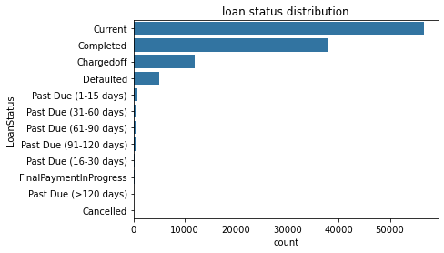

```python
color=sb.color_palette()[0];
order=df.LoanStatus.value_counts().index
sb.countplot(data=df,y="LoanStatus",color=color,order=order);
plt.title('loan status distribution');
```

we can see that the number of completed loan staus is more that the defaulted ones and also there still alot in current status

a furthur investigation we would do later is to understand why some loans were defaulted in adition we can investigate the borrowers' features who completed the loans and from this we may take a notion on how the laon requests are accepted

now let's see the employmnet status distribution in the data

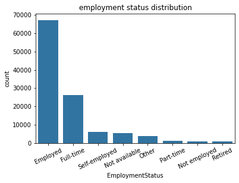

```python
# first let's understand the employment status distribution of the loan seekers
color=sb.color_palette()[0];
order=df.EmploymentStatus.value_counts().index
sb.countplot(data=df,x="EmploymentStatus",color=color,order=order)
plt.xticks(rotation=25);
plt.title('employment status distribution');
```

we can see that employees are the most likely to apply for a loan, the distribution is skewed with a less applicants with no job or retired.

Next up, let's take a notion on the stated mothly distributions

```
count    1.139370e+05
mean     5.608026e+03
std      7.478497e+03
min      0.000000e+00
25%      3.200333e+03
50%      4.666667e+03
75%      6.825000e+03
max      1.750003e+06
Name: StatedMonthlyIncome, dtype: float64
```

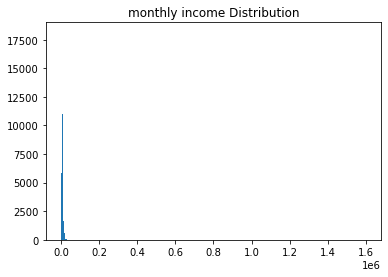

```python
#public record
print(df.StatedMonthlyIncome.describe())
bins=np.arange(0,1.6*1e6+1e3,1e3);
plt.hist(data=df,x="StatedMonthlyIncome",bins=bins);
#plt.xlim([0,0.05*1e6])
plt.title("monthly income Distribution")
```

W ecan see conclude from the above plot that the there is not much data after 0.01 *1*6 so the maximum stated in the describe function is outlier hence let's exclude them actullay after using the commented xlim youwill find that the distribtuon after 2e4 is ver samll may be negligable

```python
# select low outliers, using criteria eyeballed from the plots
x= df.StatedMonthlyIncome.describe()
high_outliers = (df.StatedMonthlyIncome > 2*1e4)
print(high_outliers.sum())
#print(df.loc[high_outliers,:])
```

```
1189
```

```python
# remove points with high outliers
df = df.loc[-high_outliers,:]
high_outliers = (df.StatedMonthlyIncome > 2*1e4)
print("outliers sum : ",high_outliers.sum())
print(df.StatedMonthlyIncome.describe())
```

```
outliers sum :  0
count    112748.000000
mean       5313.711767
std        3127.532049
min           0.000000
25%        3166.666667
50%        4583.333333
75%        6666.666667
max       20000.000000
Name: StatedMonthlyIncome, dtype: float64
```

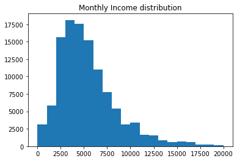

```python
bins=np.arange(0,2e4+1e3,1e3);
plt.hist(data=df,x="StatedMonthlyIncome",bins=bins);
plt.title("Monthly Income distribution");
```

we can see from the above the distribution is approximately normal distribution wih a small tail, however let's try to reduce the bin size

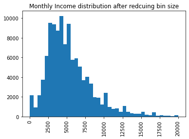

```python
bins=np.arange(0,2e4+0.5*1e3,0.5*1e3);
x=plt.hist(data=df,x="StatedMonthlyIncome",bins=bins);
plt.xticks(rotation=90);
plt.title("Monthly Income distribution after redcuing bin size");
```

We can conclude that most people in the data set have a monthly income between 4 k to 4.5 k also alot amount of people take between 5k to 5.5 k and 2.5 k to 4 k.

now let's see what are the distrbution of the terms

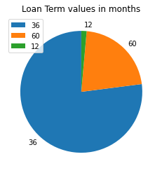

```python
# so instead of using a hist and try to adjust the x axis we would use
count=df.Term.value_counts()
labels=count.index
plt.pie(x=count,startangle=90,labels=labels);
plt.legend();
plt.title("Loan Term values in months");
```

so we can see that most people prefers to have a term of 36 months, only a very small portion may prefer to have 1 year loan term. The high demand on 36 months loan may mean one of two things the first is the bank is more selective in this category (means chose only applicants with very good profile) due to the high demand on it or it may mean that the 36 month period is more likely to be acccepted by the bank if u don't have bad prosper score so most people prefer it(ps not forgetting its suitable time to repay without feeling finnacial tight as in the case of 12 months loans nor keep being paying for too much long as in the case of the 60 month Term Loan).

we shall now see the prosper score

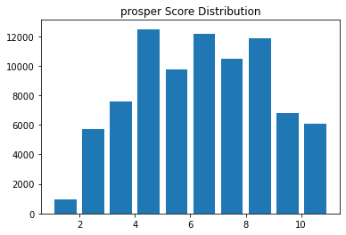

```python
# seeing insights on the prosperscore
plt.hist(data=df,x='ProsperScore',rwidth=0.8);
plt.title("prosper Score Distribution");
```

We can see that there are 11 bin, however accoriding to the data sheet the prosper score has values ranges from 1 to 10, A s a result, we're pretty sure that points at 11 is a typo or outliers. Hence we will remove it and then come back to read the plot

```python
outliers= df.ProsperScore > 10
print('number of outliers are', sum(outliers));
df = df.loc[-outliers,:]
```

```
number of outliers are 1407
```

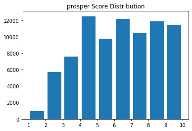

```python
bins=np.arange(1,10+1,1)
plt.hist(data=df,x='ProsperScore',bins=bins,rwidth=0.8);
plt.xticks(bins,bins);
plt.title("prosper Score Distribution");
```

excluding the first three bins, the distribution is more likely of a uniform distribution, we can see that a small proption that have a prosper score less than 4. It'd be interesting to see how loan status affected by the prosper score in the Bivarient Plot.

Now let's check the orignal loan amount

```python
df.LoanOriginalAmount.describe()
```

```
count    111341.000000
mean       8184.131066
std        6104.510321
min        1000.000000
25%        3970.000000
50%        6000.000000
75%       11500.000000
max       35000.000000
Name: LoanOriginalAmount, dtype: float64
```

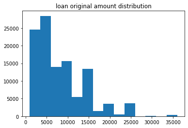

```python
bins=np.arange(1000,35000+2500,2500)
plt.hist(data=df,x='LoanOriginalAmount',bins=bins);
plt.title("loan original amount distribution");
```

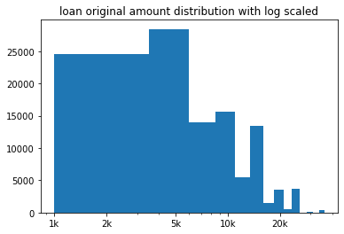

```python
# we can see from the above that the plot has a very long tail so let's put it in log scale
bins=np.arange(1000,35000+2500,2500)
plt.hist(data=df,x='LoanOriginalAmount',bins=bins);
plt.xscale('log')
plt.xticks([1e3, 2e3, 5e3, 1e4, 2e4], ['1k', '2k', '5k', '10k', '20k']);
plt.title("loan original amount distribution with log scaled");
```

Loan Orignal amount has a long-tailed distribution, with a lot of loan amount on the low price end, and few on the high price end. When plotted on a log-scale, the price distribution looks approximately unifor, with one peak between 2.5k and 5k. Interestingly, there's a steep jump in frequency right after 5000, rather than a smooth ramp up.

Next up, let's see what are Customers Principal Payement.

```
count    111341.000000
mean       3106.780064
std        4037.556894
min           0.000000
25%         509.800000
50%        1610.960000
75%        4000.000000
max       35000.000000
Name: LP_CustomerPrincipalPayments, dtype: float64
```

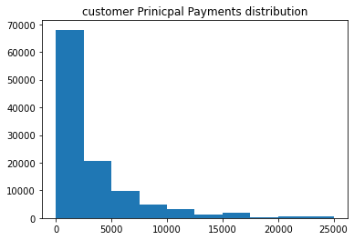

```python
print(df.LP_CustomerPrincipalPayments.describe())
bins=np.arange(0,2.5*1e4+2.5*1e3,2.5*1e3)
plt.hist(data=df,x='LP_CustomerPrincipalPayments',bins=bins);
plt.title("customer Prinicpal Payments distribution");
```

We can see from the above that the plot has a many outliers mostly all the values after the 15 k is amlost neglibale so we will remove them adn then plot a log scale due to the long tail

```python
outliers= df.LP_CustomerPrincipalPayments > 15*1e3
print('number of outliers are', sum(outliers));
df = df.loc[-outliers,:]
```

```
number of outliers are 2067
```

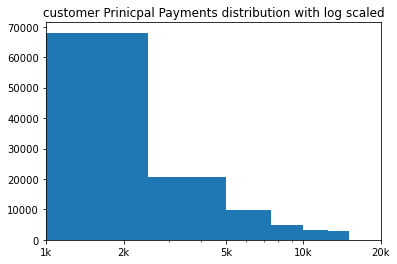

```python
# we can see from the above that the plot has a very long tail so let's put it in log scale
bins=np.arange(0,1.5*1e4+2.5*1e3,2.5*1e3)
plt.hist(data=df,x='LP_CustomerPrincipalPayments',bins=bins);
plt.xscale('log')
plt.xticks([1e3, 2e3, 5e3, 1e4, 2e4], ['1k', '2k', '5k', '10k', '20k']);
plt.title("customer Prinicpal Payments distribution with log scaled");
```

### Discuss the distribution(s) of your variable(s) of interest. Were there any unusual points? Did you need to perform any transformations?

> In LP_customerPrinicpalPayments, there was a very long tail so I tried a log scal but not a much change captured

### Of the features you investigated, were there any unusual distributions? Did you perform any operations on the data to tidy, adjust, or change the form of the data? If so, why did you do this?

> 1. In ProsperScore, there was a clear outlier as some points had a value of 11, so they were removed
> 2. In StatedMonthlyIncome and LP_CustomerPrincipalPayemnets there were alot higher outliers that were removed

## Bivariate Exploration

> In this section, investigate relationships between pairs of variables in your data. Make sure the variables that you cover here have been introduced in some fashion in the previous section (univariate exploration).

> First of all let's start by investigating the relationships between the categorical variables.

> so since we study whether a loan has completed or defaulted, I'd reduce the dataframe so that it includes only the observations that only has defaulted or completed

```python
interest_var = ( (df['LoanStatus'] == 'Completed') | (df['LoanStatus']=='Defaulted') )
df_updated=df.loc[interest_var,:]
print(df_updated.shape)
print(df_updated.LoanStatus.unique())
```

```
(40757, 81)
['Completed' 'Defaulted']
```

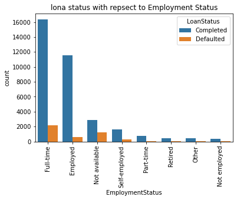

```python
# we want to see the interaction between the categorical variables

# subplot 1: LoanStatus vs EmploymentStatus
order=df_updated.EmploymentStatus.value_counts().index;
sb.countplot(data = df_updated, hue = 'LoanStatus', x = 'EmploymentStatus', order=order,palette = 'tab10');
plt.xticks(rotation=90);
plt.title("lona status with repsect to Employment Status");
```

> From above we can see that we can generally say that realtionships between Loan data with Employmnet status does not depend on a specific employment status -Excluding not available-. As we have a very large number of Loan requests at (Full-time, Employed) and on the other hand, a very low number of requests at (Part-time, Retired or not employed)

> Now let's investigate the relationship with the Term

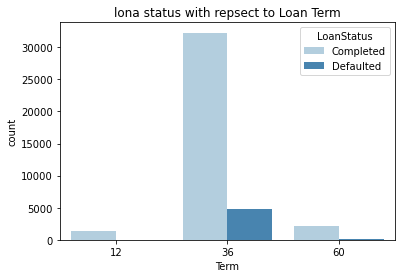

```python
# subplot 2: LoanStatus vs. Term
sb.countplot(data = df_updated, hue = 'LoanStatus', x = 'Term', palette = 'Blues');
plt.title("lona status with repsect to Loan Term");
```

> The same apply here as the above comment

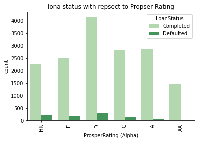

```python
# subplot 3: Loan Status vs prosper Ratings

# convert prosper Ratings  into ordered categorical types
ordinal_var = [ 'HR', 'E', 'D', 'C','A', 'AA']
ordered_var = pd.api.types.CategoricalDtype(ordered = True,
                                                categories = ordinal_var);
df_updated['ProsperRating (Alpha)'] = df_updated['ProsperRating (Alpha)'].astype(ordered_var);


sb.countplot(data = df_updated, x = 'ProsperRating (Alpha)', hue = 'LoanStatus', palette = 'Greens')
plt.xticks(rotation=90)
## interstingly emplyed people have a very big demand on the 60 months term which is interesting
plt.title("lona status with repsect to Propser Rating")
plt.show()
```

> We can see that as the Prosper Rating inis highly related to the LoanStatus and the loan status increases as the rating increases. Now let's investigate the numeric columns

> In order to visualize the data easily, I will convert the Loan status into dummy avriables and then use it's numeric value to plot the corrleation matrix

```python
df_dummies = pd.get_dummies(df_updated['LoanStatus'])
del df_dummies[df_dummies.columns[-1]]
df_updated = pd.concat([df_updated, df_dummies], axis=1)
# so now we have a int column variable called competed which has a value 1 if loan completed and 0 if defaulted
```

```python
numeric_vars=['ProsperScore','LoanOriginalAmount','LP_CustomerPrincipalPayments','StatedMonthlyIncome','Completed']
```

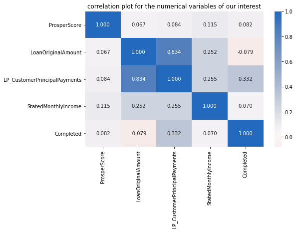

```python
# correlation plot
plt.figure(figsize = [8, 5])
sb.heatmap(df_updated[numeric_vars].corr(), annot = True, fmt = '.3f',
           cmap = 'vlag_r', center = 0)
plt.title("correlation plot for the numerical variables of our interest")
plt.show()
```

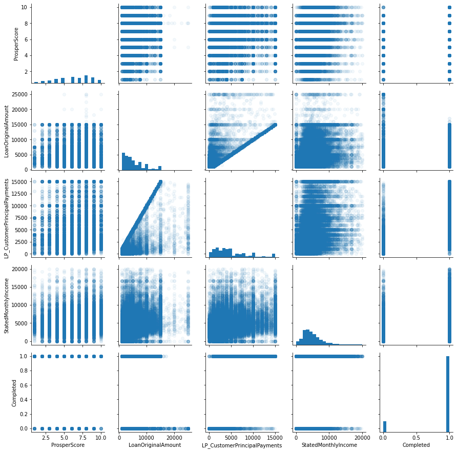

```python
# plot matrix: so by plotting the scatter plot we will be ble to see if there is a certain trend or something

g = sb.PairGrid(data = df_updated, vars = numeric_vars)
g = g.map_diag(plt.hist, bins = 20);
g.map_offdiag(plt.scatter,alpha=0.05);
```

From the heat map we can see that the loan status does not highly correlated to one variable, which was already expected as the process of accpeting a loan has to be a little complex. As a result, combining those different numberic variables may get us into more insights whether the loan status is completed or defaulted.

so up next: is to start combing those categorical variables and see whether a combination of those 2 numeric variables may be a clear indicator on the Loan status or not

### Talk about some of the relationships you observed in this part of the investigation. How did the feature(s) of interest vary with other features in the dataset?

> A direct realtion ship between the Prosper Rating and loan status was observed. as the rating improves the Loan status is more lickley to be completed

### Did you observe any interesting relationships between the other features (not the main feature(s) of interest)?

> A strong direct corrleation has been observed between Loan original amount and LP_customerPrincpalPayments

## Multivariate Exploration

> Create plots of three or more variables to investigate the data even further.

> First let's define a function that will automatibcally make the encoded plot for us then let's investigate the combination of our numeric variables from the bivarient plot

```python
def plot_encoder(data,x,y,marker,spec_col):
    '''
    the function is used to make scatter plots
    note taht x,y, and spec_col have to be strigns and represents col names in data
    x and y has to be numeric
    marker should be a list consists of two elements 1. the value in spec_col that u want to plot 2. marker shape to be ploted
    '''
    dummy=data[data[spec_col]==marker[0]]
    plt.scatter(data=dummy,x=x,y=y,marker=marker[1],alpha=0.5);
    plt.xlabel(x)
    plt.ylabel(y)
```

```python
status_marker=[['Completed','o'],
              ['Defaulted','^']]
```

Let's start with Loan Orignialamount vs StatedMonthlyIncome

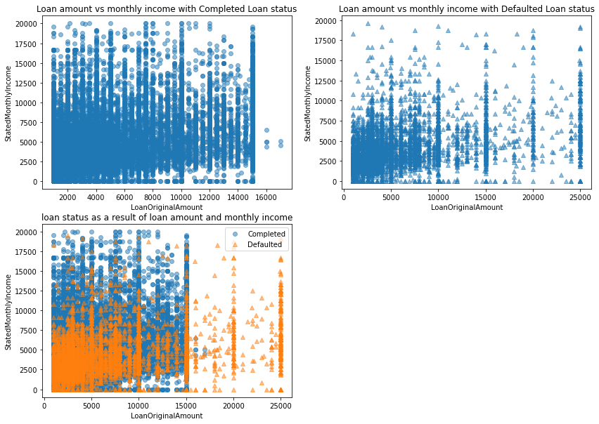

```python
# let's see  the distributiom of the completed and defaulted
#in two sperated plot at first so that when we plot them on each other
# we won't be decieved by the overlap of the second plotted variable
plt.figure(figsize=[14, 10])
for i in range(len(status_marker)):
    plt.subplot(2,2,i+1)
    x="Loan amount vs monthly income with "+status_marker[i][0]+" Loan status"
    plt.title(x);
    plot_encoder(df_updated,'LoanOriginalAmount','StatedMonthlyIncome',status_marker[i],'LoanStatus')
    plt.subplot(2,2,3)
    plot_encoder(df_updated,'LoanOriginalAmount','StatedMonthlyIncome',status_marker[i],'LoanStatus')
plt.title("loan status as a result of loan amount and monthly income");

plt.legend(['Completed','Defaulted']);
```

> Now let's see the LoanOrignalAmount vs the Prosperscore

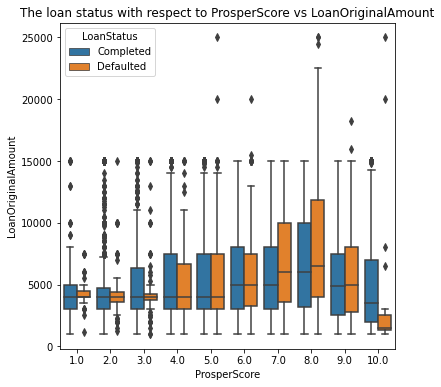

```python
# make a box plot
plt.figure(figsize=[6, 6])
sb.boxplot(data=df_updated, x='ProsperScore', y='LoanOriginalAmount', hue='LoanStatus');
plt.title("The loan status with respect to ProsperScore vs LoanOriginalAmount");
```

This visualzation was not quite informative however we can notice the following: most likely the median of the defaulted loans is approximately the same if not exactly the same to the median of the completed loans. excluding from the previos, prosper scores equivalent to 7,8,10 where in proscper score= 10 the median of the proscperscore is much greater than that of defaulted. While in both 7 and 8 the median of defaulted loans is greater thant that of completed which makes no sense as, the propser score is a scale from 1 to 10 where 1 represents the worst and 10 represnets the best customer segment.

In addition we can see alot of outliers in the case of prosper score =2 ,and prosper score = 3

> Finally Let's check our last visual which includes the Loan amount vs customerprincipalPayemnts and their influecne on the Loan status

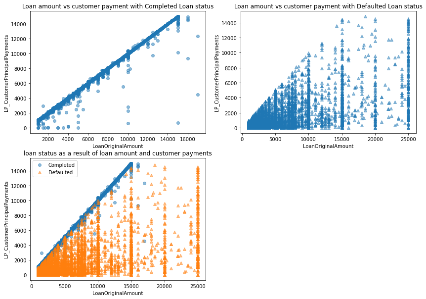

```python
plt.figure(figsize=[14, 10])

for i in range(len(status_marker)):
    plt.subplot(2,2,i+1)
    x="Loan amount vs customer payment with "+status_marker[i][0]+" Loan status"
    plt.title(x)
    plot_encoder(df_updated,'LoanOriginalAmount','LP_CustomerPrincipalPayments',status_marker[i],'LoanStatus')
    plt.subplot(2,2,3)
    plot_encoder(df_updated,'LoanOriginalAmount','LP_CustomerPrincipalPayments',status_marker[i],'LoanStatus')
plt.title("loan status as a result of loan amount and customer payments")
plt.legend(['Completed','Defaulted'])
plt.show();
```

### Were there any interesting or surprising interactions between features?

> some loan requested has been defaulted even for clients with prosper score = 10 because they did not achieve the thereshold of loan amount vs the prinicpal payment. In addition, many clients with low prosper score have had a dsitribtuin similar to clients with higher score with respect to the loan amount. to conclude that the prosper score doesn't really matter

```python
# exporintg tidy data
vars=['ProsperScore','LoanOriginalAmount','LP_CustomerPrincipalPayments','StatedMonthlyIncome','Completed',
      'ProsperRating (Alpha)','LoanStatus']
tidy=df_updated[vars]
tidy.to_csv("loan_tidy.csv",index=False)
```